# Makeover Monday 2019 Week 45: UNESCO Global Literacy Rates

Data Wrangling and Exploratory Analysis

Clare Gibson

2021-11-23

# 1 Introduction

This week’s [Makeover Monday (MM)](https://www.makeovermonday.co.uk/) challenge looks at global youth and adult literacy rates. The data was compiled by [UNESCO](https://en.unesco.org/) as part of the [Global Education 2030 Agenda](https://unesdoc.unesco.org/ark:/48223/pf0000245656) [Sustainable Development Goal (SDG) 4](https://unesdoc.unesco.org/ark:/48223/pf0000259784). The particular focus for this challenge was [SDG 4.6](https://en.unesco.org/node/265600) which states:

> By 2030, ensure that all youth and a substantial proportion of adults, both men and women, achieve literacy and numeracy.

## 1.1 The Original Viz

The original viz this week was a UNESCO Dashboard reflecting the current state of youth literacy across the globe. It appears to have been built as part of the analysis of SDG 4.6.

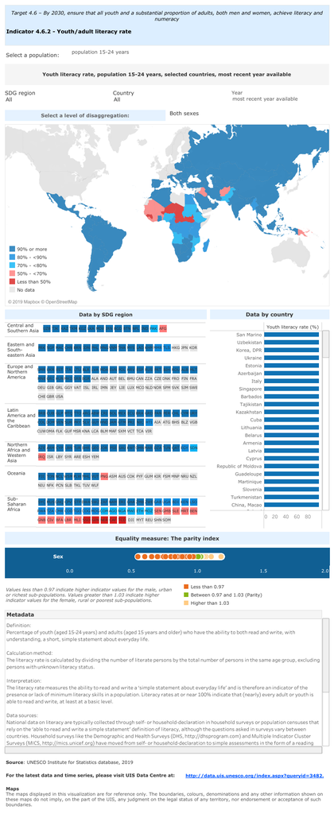

UNESCO Global Literacy Dashboard

Unfortunately, the original article to which this visualisation belonged is no longer available. The original dataset provided for the MM challenge can be found [here](https://data.world/makeovermonday/2019w46).

### 1.1.1 What I Liked

- Clear use of contrasting colour to differentiate low literacy rates from high ones. The colour tone shifts from blue to red at the 70% level so I assume that anything below 70% is considered low.
- The Sustainable Development target that this dashboard represents is clearly stated.
- Enough information has been provided to understand that the map represents literacy rates for the population aged 15-24, for both sexes and for the most recent year of available data.
- The highlight table does allow us to see the number of countries within each region that have low literacy rates.
- Metadata is thoroughly explained.

### 1.1.2 What I Didn’t Like

- This dashboard gives no indication of trends over time so it is difficult to tell which countries may be on track for achieving the goal by 2030.
- The ‘Data By Country’ bar chart on the bottom-right seems a little pointless as it is not able to show every country, and the ones it does show are all at 100%, therefore there is no difference in bar height.
- I don’t really understand the ‘Parity Index’ chart at the bottom of the dashboard. It’s not clear to me what each dot represents. A country? I think it is supposed to show me that most of the global illiteracy is among female, rural or poor sub-populations, but this could do with being better explained.
- I don’t like that there are some (significant) countries for which no data is available. I know this is not the fault of the original chart designers but I hate missing data!

## 1.2 My Intentions

I am going to focus on just the youth part of the 2030 literacy goal, that is that all countries should achieve full (100%) literacy among their youth (15-24 years) population by 2030.

Since I am working on this project in 2021, I decided to go to the [original data source](http://data.uis.unesco.org/index.aspx?queryid=3482) and gather data for more recent years. I also decided to go back a little further than the original challenge, so my data looks at literacy rates between 2000 and 2021. I am hoping that this wider range of years will allow me to better explore the progress that countries are making towards the 2030 UNESCO youth goal.

I would also like to explore which countries are the biggest contributors to global youth illiteracy, by looking at the data in terms of proportion of global youth population. To do this, I’ll need to bring in some additional data on population estimates by country.

## 1.3 Questions

- Which countries are still working towards the 2030 youth literacy goal?
- Which countries are the biggest contributors to global youth illiteracy?
- Which countries are on track to achieve the 2030 youth literacy goal?
- Which countries are likely not to achieve the 2030 youth literacy goal?

# 2 Set-up

First I will load the packages needed for this EDA.

```r
library(tidyverse)   # for lots of wrangling functions
library(janitor)     # for cleaning column headings
library(ggplot2)     # for plots
```

Now I will read in the data for this project. First I’ll define the paths where it is located, then read in the CSV files.

```r
# path to the literacy data
path_lit <- "data/2019-wk46-data-literacy-2000-2021.csv"

# path to the population data
path_pop <- "data/2019-wk46-data-population-2000-2020.csv"

# read in the literacy data
lit <- read_csv(path_lit)

# read in the population data
pop <- read_csv(path_pop)
```

# 3 Inspection

I’ll take a look at the first few rows of each dataset.

```r
# look at the first few rows of the literacy data
# the kable function is used for table styling only
lit %>%
  head(3) %>%
  kable()
```

| SDG_IND | Indicator | LOCATION | Country | TIME | Time | Value | Flag Codes | Flags |
| --- | --- | --- | --- | --- | --- | --- | --- | --- |
| LR_AG15T24_F | Youth literacy rate, population 15-24 years, female (%) | 40656 | Oceania (excl. Australia/New Zealand) | 2000 | 2000 | 72.17386 | NA | NA |
| LR_AG15T24_F | Youth literacy rate, population 15-24 years, female (%) | 40656 | Oceania (excl. Australia/New Zealand) | 2001 | 2001 | 72.64066 | NA | NA |
| LR_AG15T24_F | Youth literacy rate, population 15-24 years, female (%) | 40656 | Oceania (excl. Australia/New Zealand) | 2002 | 2002 | 73.07147 | NA | NA |

```r
# look at the first few rows of the population data
pop %>%
  head(3) %>%
  kable()
```

| DEMO_IND | Indicator | LOCATION | Country | TIME | Time | Value | Flag Codes | Flags |
| --- | --- | --- | --- | --- | --- | --- | --- | --- |
| SP_POP_GROW | Population growth (annual %) | AUS | Australia | 2000 | 2000 | 1.2 | NA | NA |
| SP_POP_GROW | Population growth (annual %) | AUS | Australia | 2001 | 2001 | 1.3 | NA | NA |
| SP_POP_GROW | Population growth (annual %) | AUS | Australia | 2002 | 2002 | 1.2 | NA | NA |

## 3.1 General Properties

I like to start my data inspections by looking at some general properties of each dataset:

- Are the column headings clean and in an R-friendly format?
- Are there any duplicated rows?
- Are there any missing values?
- Is there a unique identifier for each row?

### 3.1.1 Column Headings

For cleaning the column headings, the `janitor` package has a handy function.

```r
# clean column headings of literacy data
lit <- lit %>%
  clean_names()

# clean column headings of population data
pop <- pop %>%
  clean_names()
```

### 3.1.2 Duplicates

Are there any duplicated rows?

```r
# check for duplicated rows in the literacy data
lit %>%
  duplicated() %>%
  table() %>%
  kable()
```

| . | Freq |
| --- | --- |
| FALSE | 16190 |

```r
# check for duplicated rows in the population data
pop %>%
  duplicated() %>%
  table() %>%
  kable()
```

| . | Freq |
| --- | --- |
| FALSE | 32591 |

There are no duplicated rows in either dataset.

### 3.1.3 Missing Values

Are there any missing values in any of the columns? Credit to [this SO thread](https://stackoverflow.com/questions/24027605/determine-the-number-of-na-values-in-a-column) for helping me determine the number of missing values in each column of a dataframe.

```r
# count the number of missing values in each column of the
# literacy data
colSums(is.na(lit))
```

```
##    sdg_ind  indicator   location    country       time     time_2      value
##          0          0          0          0          0          0          0
## flag_codes      flags
##      14025      14025
```

```r
# count the number of missing values in each column of the
# population data
colSums(is.na(pop))
```

```
##   demo_ind  indicator   location    country       time     time_2      value
##          0          0          0          0          0          0        576
## flag_codes      flags
##      32015      32015
```

Both datasets have missing values in the `flag_codes` and `flags` columns. This should not be an issue as the flags are only included if there are caveats that need to be mentioned for the data for that row. The `pop` dataset also has missing values in `value`. I will filter it down to see where these are.

```r
pop %>%
  # filter to records with missing data in value
  filter(is.na(value)) %>%
  # show a few examples across different indicators
  group_by(indicator) %>%
  slice_head(n=2) %>%
  kable()
```

| demo_ind | indicator | location | country | time | time_2 | value | flag_codes | flags |
| --- | --- | --- | --- | --- | --- | --- | --- | --- |
| 200343 | Population aged 14 years or younger (thousands) | NIU | Niue | 2004 | 2004 | NA | n | Magnitude nil or negligible |
| 200343 | Population aged 14 years or younger (thousands) | NIU | Niue | 2005 | 2005 | NA | n | Magnitude nil or negligible |
| 200144 | Population aged 15-24 years (thousands) | TKL | Tokelau | 2000 | 2000 | NA | n | Magnitude nil or negligible |
| 200144 | Population aged 15-24 years (thousands) | TKL | Tokelau | 2001 | 2001 | NA | n | Magnitude nil or negligible |
| 200345 | Population aged 25-64 years (thousands) | TKL | Tokelau | 2004 | 2004 | NA | n | Magnitude nil or negligible |
| 200345 | Population aged 25-64 years (thousands) | TKL | Tokelau | 2005 | 2005 | NA | n | Magnitude nil or negligible |
| 200151 | Population aged 65 years or older (thousands) | FLK | Falkland Islands (Malvinas) | 2000 | 2000 | NA | n | Magnitude nil or negligible |
| 200151 | Population aged 65 years or older (thousands) | FLK | Falkland Islands (Malvinas) | 2001 | 2001 | NA | n | Magnitude nil or negligible |
| SP_POP_GROW | Population growth (annual %) | CZE | Czechia | 2004 | 2004 | NA | n | Magnitude nil or negligible |
| SP_POP_GROW | Population growth (annual %) | CZE | Czechia | 2013 | 2013 | NA | n | Magnitude nil or negligible |
| SP_RUR_TOTL_ZS | Rural population (% of total population) | BMU | Bermuda | 2000 | 2000 | NA | n | Magnitude nil or negligible |
| SP_RUR_TOTL_ZS | Rural population (% of total population) | BMU | Bermuda | 2001 | 2001 | NA | n | Magnitude nil or negligible |

It looks like the missing values are in low population countries where the value for a particular demographic may be negligible. I will generate a list of all of the countries that are affected by missing values.

```r
pop %>%
  # filter to rows with missing values
  filter(is.na(value)) %>%
  # show the number of missing values by country
  group_by(indicator,
           country) %>%
  summarise(count = n()) %>%
  kable()
```

| indicator | country | count |
| --- | --- | --- |
| Population aged 14 years or younger (thousands) | Falkland Islands (Malvinas) | 10 |
| Population aged 14 years or younger (thousands) | Holy See | 21 |
| Population aged 14 years or younger (thousands) | Niue | 17 |
| Population aged 14 years or younger (thousands) | Tokelau | 17 |
| Population aged 15-24 years (thousands) | Falkland Islands (Malvinas) | 21 |
| Population aged 15-24 years (thousands) | Holy See | 21 |
| Population aged 15-24 years (thousands) | Montserrat | 5 |
| Population aged 15-24 years (thousands) | Niue | 21 |
| Population aged 15-24 years (thousands) | Tokelau | 21 |
| Population aged 25-64 years (thousands) | Holy See | 21 |
| Population aged 25-64 years (thousands) | Tokelau | 11 |
| Population aged 65 years or older (thousands) | Falkland Islands (Malvinas) | 11 |
| Population aged 65 years or older (thousands) | Holy See | 21 |
| Population aged 65 years or older (thousands) | Montserrat | 10 |
| Population aged 65 years or older (thousands) | Nauru | 21 |
| Population aged 65 years or older (thousands) | Niue | 21 |
| Population aged 65 years or older (thousands) | Saint Helena | 10 |
| Population aged 65 years or older (thousands) | Tokelau | 21 |
| Population aged 65 years or older (thousands) | Tuvalu | 8 |
| Population growth (annual %) | American Samoa | 1 |
| Population growth (annual %) | Andorra | 1 |
| Population growth (annual %) | Belarus | 1 |
| Population growth (annual %) | Bosnia and Herzegovina | 2 |
| Population growth (annual %) | Croatia | 3 |
| Population growth (annual %) | Cuba | 1 |
| Population growth (annual %) | Czechia | 2 |
| Population growth (annual %) | Dominica | 5 |
| Population growth (annual %) | Estonia | 1 |
| Population growth (annual %) | Faeroe Islands | 1 |
| Population growth (annual %) | Georgia | 2 |
| Population growth (annual %) | Gibraltar | 1 |
| Population growth (annual %) | Greenland | 1 |
| Population growth (annual %) | Guyana | 4 |
| Population growth (annual %) | Isle of Man | 1 |
| Population growth (annual %) | Italy | 1 |
| Population growth (annual %) | Japan | 4 |
| Population growth (annual %) | Kazakhstan | 1 |
| Population growth (annual %) | Lesotho | 1 |
| Population growth (annual %) | Lithuania | 1 |
| Population growth (annual %) | Mauritius | 2 |
| Population growth (annual %) | Montenegro | 2 |
| Population growth (annual %) | North Macedonia | 2 |
| Population growth (annual %) | Poland | 2 |
| Population growth (annual %) | Portugal | 2 |
| Population growth (annual %) | Puerto Rico | 3 |
| Population growth (annual %) | Russian Federation | 2 |
| Population growth (annual %) | Saint Vincent and the Grenadines | 1 |
| Population growth (annual %) | Slovakia | 3 |
| Population growth (annual %) | United States Virgin Islands | 2 |
| Population growth (annual %) | Uruguay | 2 |
| Rural population (% of total population) | Bermuda | 21 |
| Rural population (% of total population) | Cayman Islands | 21 |
| Rural population (% of total population) | China, Hong Kong Special Administrative Region | 21 |
| Rural population (% of total population) | China, Macao Special Administrative Region | 21 |
| Rural population (% of total population) | Gibraltar | 21 |
| Rural population (% of total population) | Kuwait | 20 |
| Rural population (% of total population) | Monaco | 21 |
| Rural population (% of total population) | Nauru | 21 |
| Rural population (% of total population) | Singapore | 21 |
| Rural population (% of total population) | Sint Maarten (Dutch part) | 21 |

As I thought, the missing values for the population count indicators are all in small countries. It is likely that these countries are not even included in the `lit` dataset so I may not need those observations for my analysis.

### 3.1.4 Unique Identifier

There is no single column which uniquely identifies each observation in either of these datasets. However, the combination of `indicator`, `location` and `time` should be unique. I will check if this is true in both datasets.

```r
# count the number of distinct rows by indicator, location and time
# save this number to a variable
c <- lit %>%
  distinct(indicator, location, time) %>%
  nrow()

# check that this number matches the total number of rows in lit
c == nrow(lit)
```

```
## [1] TRUE
```

```r
# count the number of distinct rows by indicator, location and time
# save this number to a variable
d <- pop %>%
  distinct(indicator, location, time) %>%
  nrow()

# check that this number matches the total number of rows in lit
d == nrow(pop)
```

```
## [1] TRUE
```

Both outcomes are true therefore, I do have a unique identifier for each row if I combine `indicator`, `location` and `time`. No cleaning required here.

## 3.2 Inspecting the Data

I will `glimpse` each dataset to find out the data types of each column.

```r
# glimpse the literacy data
glimpse(lit)
```

```
## Rows: 16,190
## Columns: 9
## $ sdg_ind    <chr> "LR_AG15T24_F", "LR_AG15T24_F", "LR_AG15T24_F", "LR_AG15T24…
## $ indicator  <chr> "Youth literacy rate, population 15-24 years, female (%)", …
## $ location   <chr> "40656", "40656", "40656", "40656", "40656", "40656", "4065…
## $ country    <chr> "Oceania (excl. Australia/New Zealand)", "Oceania (excl. Au…
## $ time       <dbl> 2000, 2001, 2002, 2003, 2004, 2005, 2006, 2007, 2008, 2009,…
## $ time_2     <dbl> 2000, 2001, 2002, 2003, 2004, 2005, 2006, 2007, 2008, 2009,…
## $ value      <dbl> 72.17386, 72.64066, 73.07147, 73.47742, 73.91364, 74.37333,…
## $ flag_codes <chr> NA, NA, NA, NA, NA, NA, NA, NA, NA, NA, NA, "‡", NA, NA, NA…
## $ flags      <chr> NA, NA, NA, NA, NA, NA, NA, NA, NA, NA, NA, "UIS Estimation…
```

```r
# glimpse the population data
glimpse(pop)
```

```
## Rows: 32,591
## Columns: 9
## $ demo_ind   <chr> "SP_POP_GROW", "SP_POP_GROW", "SP_POP_GROW", "SP_POP_GROW",…
## $ indicator  <chr> "Population growth (annual %)", "Population growth (annual …
## $ location   <chr> "AUS", "AUS", "AUS", "AUS", "AUS", "AUS", "AUS", "AUS", "AU…
## $ country    <chr> "Australia", "Australia", "Australia", "Australia", "Austra…
## $ time       <dbl> 2000, 2001, 2002, 2003, 2004, 2005, 2006, 2007, 2008, 2009,…
## $ time_2     <dbl> 2000, 2001, 2002, 2003, 2004, 2005, 2006, 2007, 2008, 2009,…
## $ value      <dbl> 1.2, 1.3, 1.2, 1.2, 1.2, 1.3, 1.5, 0.6, 2.0, 2.1, 1.6, 1.4,…
## $ flag_codes <chr> NA, NA, NA, NA, NA, NA, NA, NA, NA, NA, NA, NA, NA, NA, NA,…
## $ flags      <chr> NA, NA, NA, NA, NA, NA, NA, NA, NA, NA, NA, NA, NA, NA, NA,…
```

Some observations here:

- In the `lit` data, the `value` column represents the literacy rate, which is the percentage of the relevant population that is literate. The values are expressed as numbers between 0 and 100. For the purposes of working in Tableau later, I would prefer these to be expressed as decimals between 0 and 1.
- In the `pop` data, the `value` column represents the population count (for some of the `indicator` values). The population counts are expressed in thousands. For the purposes of working in Tableau later I would prefer these to be converted to the full number by multiplying by 1000.
- I will drop the `sdg_ind` column from `lit` and the `demo_ind` column from `pop` as these are just codified versions of the `indicator` column in each dataset.
- I should inspect the unique values of the categorical columns (`indicator`, `location`, `country`, `flag_codes` and `flags`) in each dataset to get a feel for how many levels there are, whether any levels should be dropped and whether the naming conventions are consistent between datasets.
- I should inspect the numerical columns to get a feel for the shape of the data and whether there are any outliers.
- There are two columns for the year in each dataset (named `time` and `time_2`). I will inspect these more closely to check if the values are identical. If they are then I can drop the `time_2` column.
- I will need to be careful when performing any aggregations on the `value` column in each dataset, because the values could be expressed in different units depending on the `indicator`.

### 3.2.1 Unique Values for Categorical Variables

#### 3.2.1.1 `indicator`

I will first take a look at the `indicator` column of each dataset and find out what are the unique values and how many observations each unique value belongs to.

```r
# get value counts for indicator column of literacy data
lit %>%
  count(indicator) %>%
  kable()
```

| indicator | n |
| --- | --- |
| Adult literacy rate, population 15+ years, both sexes (%) | 1361 |
| Adult literacy rate, population 15+ years, female (%) | 1364 |
| Adult literacy rate, population 15+ years, male (%) | 1358 |
| Elderly literacy rate, population 65+ years, both sexes (%) | 1337 |
| Elderly literacy rate, population 65+ years, female (%) | 1336 |
| Elderly literacy rate, population 65+ years, male (%) | 1337 |
| Literacy rate, population 25-64 years, both sexes (%) | 1343 |
| Literacy rate, population 25-64 years, female (%) | 1346 |
| Literacy rate, population 25-64 years, male (%) | 1339 |
| Youth literacy rate, population 15-24 years, both sexes (%) | 1356 |
| Youth literacy rate, population 15-24 years, female (%) | 1356 |
| Youth literacy rate, population 15-24 years, male (%) | 1357 |

All of the levels look good for the literacy data.

```r
# get value counts for indicator column of population data
pop %>%
  count(indicator) %>%
  kable()
```

| indicator | n |
| --- | --- |
| Population aged 14 years or younger (thousands) | 4723 |
| Population aged 15-24 years (thousands) | 4723 |
| Population aged 25-64 years (thousands) | 4723 |
| Population aged 65 years or older (thousands) | 4723 |
| Population growth (annual %) | 4470 |
| Rural population (% of total population) | 4506 |
| Total population (thousands) | 4723 |

For the population dataset, I can drop the rows that are expressed as a percentage (‘Population growth (annual %)’ and ‘Rural population (% of total population)’) as these are not useful to my analysis. This will also help to eliminate some of the rows that have missing data.

#### 3.2.1.2 `location` and `country`

Now I will obtain a list of the unique values of the `location` column in each dataset. Value counts are not so important here, but I would like to check for consistency between the two datasets.

```r
# generate a list of unique values for the location column in lit
lit_locations <- unique(lit$location)
length(lit_locations)
```

```
## [1] 194
```

```r
# generate a list of unique values for the location column in pop
pop_locations <- unique(pop$location)
length(pop_locations)
```

```
## [1] 233
```

There are 194 unique location values in `lit` and 233 in `pop`. I will explore how many of the values in `lit` are not present in `pop`.

```r
# which of the unique values in lit are not present in pop?
lit %>%
  select(location, country) %>%
  distinct() %>%
  filter(!location %in% pop_locations) %>%
  kable()
```

| location | country |
| --- | --- |
| 40656 | Oceania (excl. Australia/New Zealand) |
| 40611 | Asia (Eastern) |
| 40606 | Africa (Sub-Saharan) |
| 40613 | Asia (South-eastern) |
| 40334 | Least Developed Countries |
| 40618 | Asia (Central and Southern) |
| 40505 | Central Asia |
| 40515 | East Asia and the Pacific |
| 40540 | Sub-Saharan Africa |
| 40612 | Asia (Central) |
| 40344 | Small Island Developing States |
| 40530 | Central and Eastern Europe |
| 40535 | South and West Asia |
| 40044 | Low income countries |
| 40614 | Asia (Western) |
| 40042 | Lower middle income countries |
| 40617 | Western Asia and Northern Africa |
| 40525 | Arab States |
| 40550 | Small Island Developing States |
| 40616 | Asia (Southern) |
| 40043 | Upper middle income countries |
| 40510 | World |
| 40603 | Africa (Northern) |
| 40030 | Middle income countries |
| 40630 | Latin America and the Caribbean |
| 40330 | Landlocked Developing Countries |
| 40675 | World |
| 40620 | Europe |
| 40619 | Asia (Eastern and South-eastern) |
| 40520 | Latin America and the Caribbean |
| XDN | Sudan (pre-secession) |

Most of these values relate to aggregations of countries such as `Europe` or `Upper middle income countries`, so I would not expect them to be present in the population dataset. There is however, one country code, `XDN`. This is for Sudan (pre-secession).

Are there any other values for Sudan in the `lit` dataset? Which years are covered by each value?

```r
# find instances of 'Sudan' in the lit dataset
lit %>%
  filter(grepl("Sudan", country)) %>%
  group_by(location, country) %>%
  summarise(min_year = min(time),
            max_year = max(time)) %>%
  kable()
```

| location | country | min_year | max_year |
| --- | --- | --- | --- |
| SDN | Sudan | 2000 | 2018 |
| SSD | South Sudan | 2008 | 2018 |
| XDN | Sudan (pre-secession) | 2000 | 2000 |

What values for Sudan exist in the `pop` dataset? Which years are covered by each value?

```r
# find instances of 'Sudan' in the pop dataset
pop %>%
  filter(grepl("Sudan", country)) %>%
  group_by(location, country) %>%
  summarise(min_year = min(time),
            max_year = max(time)) %>%
  kable()
```

| location | country | min_year | max_year |
| --- | --- | --- | --- |
| SDN | Sudan | 2000 | 2020 |
| SSD | South Sudan | 2000 | 2020 |

#### 3.2.1.3 `flag_codes` and `flags`

I will look at the `flag_codes` and `flags` columns of each dataset and find out what are the unique values and how many observations each unique value belongs to.

```r
# get value counts for flag columns of literacy data
lit %>%
  count(flag_codes, flags) %>%
  kable()
```

| flag_codes | flags | n |
| --- | --- | --- |
| ‡ | UIS Estimation | 2060 |
| + | National Estimation | 105 |
| NA | NA | 14025 |

In then literacy data the flags simply indicate when a value was estimated, and by whom.

```r
# get value counts for flag columns of population data
pop %>%
  count(flag_codes, flags) %>%
  kable()
```

| flag_codes | flags | n |
| --- | --- | --- |
| n | Magnitude nil or negligible | 576 |
| NA | NA | 32015 |

In the population data the flags indicate when a value was nil or negligible. These flags indicate the missing values.

### 3.2.2 Year Columns

There are two columns for the year in each dataset (named `time` and `time_2`). I will inspect these more closely to check if the values are identical.

```r
# compare values in time and time_2 to find any that differ
lit %>%
  # select the 2 time columns
  select(time, time_2) %>%
  # add a column to determine if the two values match
  mutate(match = time == time_2) %>%
  # filter for any records that do not match
  filter(match == FALSE)
```

```
## # A tibble: 0 x 3
## # … with 3 variables: time <dbl>, time_2 <dbl>, match <lgl>
```

```r
# compare values in time and time_2 to find any that differ
pop %>%
  # select the 2 time columns
  select(time, time_2) %>%
  # add a column to determine if the two values match
  mutate(match = time == time_2) %>%
  # filter for any records that do not match
  filter(match == FALSE)
```

```
## # A tibble: 0 x 3
## # … with 3 variables: time <dbl>, time_2 <dbl>, match <lgl>
```

This code returns 0 rows in both datasets, therefore there are no records where the value in `time` differs from the value in `time_2`. I can drop the `time_2` column from both datasets. It will also be helpful to rename the `time` column to `year` so that it better describes the data within.

### 3.2.3 Numerical Columns

I can now take a look at the numerical columns to get a feel for the shape of the data and whether there are any outliers.

#### 3.2.3.1 Literacy data

I’ll start by inspecting the numerical columns in the literacy dataset.

```r
# run the numerical summary for the lit dataset
lit %>%
  select_if(is.numeric) %>%
  summary() %>%
  kable()
```

|  | time | time_2 | value |
| --- | --- | --- | --- |
|  | Min. :2000 | Min. :2000 | Min. : 0.1902 |
|  | 1st Qu.:2006 | 1st Qu.:2006 | 1st Qu.: 66.1203 |
|  | Median :2011 | Median :2011 | Median : 86.3145 |
|  | Mean :2010 | Mean :2010 | Mean : 78.1272 |
|  | 3rd Qu.:2015 | 3rd Qu.:2015 | 3rd Qu.: 96.7496 |
|  | Max. :2021 | Max. :2021 | Max. :100.0000 |

Credit to [this article](https://r-charts.com/distribution/histogram-boxplot/) for helping me plot a histogram and box plot together.

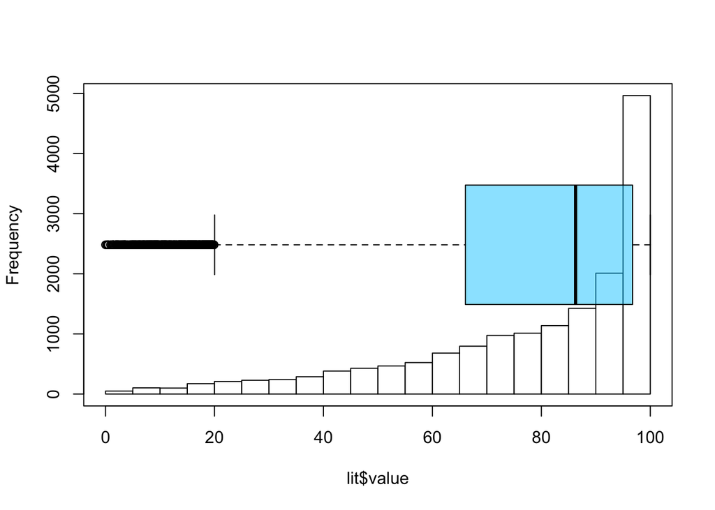

```r
# plot a histogram and box plot for the value column in lit
# histogram
hist(lit$value,
     col = "white",
     main = "")

# add new plot
par(new = TRUE)

# box plot
boxplot(lit$value, horizontal = TRUE, axes = FALSE,
        col = rgb(0, 0.8, 1, alpha = 0.5))

# box around the plots
box()
```

This is a clearly left-skewed variable. Most of the values are close to 100% (the median is 86%), but there are several outliers that fall below 20%. I can zone in on these lowest values to find out which countries, indicators and years they represent.

```r
# find the lowest 20 values in the lit dataset
lit %>%
  select(indicator, country, time, value) %>%
  arrange(value) %>%
  head(20) %>%
  kable()
```

| indicator | country | time | value |
| --- | --- | --- | --- |
| Elderly literacy rate, population 65+ years, female (%) | Chad | 2000 | 0.19023 |
| Elderly literacy rate, population 65+ years, female (%) | Sierra Leone | 2013 | 0.40250 |
| Elderly literacy rate, population 65+ years, female (%) | Chad | 2015 | 0.54559 |
| Elderly literacy rate, population 65+ years, female (%) | Ethiopia | 2005 | 0.71649 |
| Elderly literacy rate, population 65+ years, female (%) | Sierra Leone | 2018 | 0.71783 |
| Elderly literacy rate, population 65+ years, female (%) | Burkina Faso | 2003 | 1.08790 |
| Elderly literacy rate, population 65+ years, female (%) | Burkina Faso | 2006 | 1.16097 |
| Elderly literacy rate, population 65+ years, female (%) | Benin | 2012 | 1.35646 |
| Elderly literacy rate, population 65+ years, female (%) | Yemen | 2004 | 1.50000 |
| Elderly literacy rate, population 65+ years, female (%) | Mali | 2010 | 1.56074 |
| Elderly literacy rate, population 65+ years, female (%) | Gambia | 2013 | 1.59539 |
| Elderly literacy rate, population 65+ years, female (%) | Niger | 2005 | 1.66116 |
| Elderly literacy rate, population 65+ years, female (%) | Niger | 2001 | 1.66827 |
| Elderly literacy rate, population 65+ years, female (%) | Afghanistan | 2011 | 2.04137 |
| Elderly literacy rate, population 65+ years, female (%) | Benin | 2006 | 2.07895 |
| Elderly literacy rate, population 65+ years, female (%) | Burkina Faso | 2014 | 2.08437 |
| Elderly literacy rate, population 65+ years, both sexes (%) | Niger | 2001 | 2.10702 |
| Elderly literacy rate, population 65+ years, female (%) | Benin | 2018 | 2.27464 |
| Elderly literacy rate, population 65+ years, female (%) | Afghanistan | 2021 | 2.29657 |
| Elderly literacy rate, population 65+ years, female (%) | Guinea | 2010 | 2.32445 |

These extremely low values are largely associated with elderly, female literacy rates across sub-Saharan Africa. It is good to be aware of this.

#### 3.2.3.2 Population Data

I can now look at the numerical columns of the population data.

```r
# run the numerical summary for the pop dataset
pop %>%
  select_if(is.numeric) %>%
  summary() %>%
  kable()
```

|  | time | time_2 | value |
| --- | --- | --- | --- |
|  | Min. :2000 | Min. :2000 | Min. : -4.5 |
|  | 1st Qu.:2005 | 1st Qu.:2005 | 1st Qu.: 19.0 |
|  | Median :2010 | Median :2010 | Median : 232.0 |
|  | Mean :2010 | Mean :2010 | Mean : 8853.3 |
|  | 3rd Qu.:2015 | 3rd Qu.:2015 | 3rd Qu.: 3257.0 |
|  | Max. :2020 | Max. :2020 | Max. :1439324.0 |
|  | NA | NA | NA’s :576 |

Again, the `time` and `time_2` columns look as expected with values ranging from 2000 to 2020, which was the range of years I selected for the data.

One thing to note here is that the latest year in the population data is 2020, whereas in the literacy data it is 2021. I would like to include an estimate of 2021 population data, so I will attempt to impute this value for each country.

I need to be careful with the `value` column, however, because the data in that column is expressed in different units according to the indicator it represents. It would be more helpful to see summaries grouped by `indicator` here.

```r
# create a statistical summary for value in population,
# grouped by indicator, with missing values removed
pop %>%
  filter(!is.na(value)) %>%
  group_by(indicator) %>%
  summarise(min = min(value),
            q1 = quantile(value, 0.25),
            median = median(value),
            q3 = quantile(value, 0.75),
            max = max(value),
            mean = mean(value),
            sd = sd(value)) %>%
  kable()
```

| indicator | min | q1 | median | q3 | max | mean | sd |
| --- | --- | --- | --- | --- | --- | --- | --- |
| Population aged 14 years or younger (thousands) | 1.0 | 101.0 | 1253.5 | 6081.50 | 380433.0 | 8363.51524 | 3.225801e+04 |
| Population aged 15-24 years (thousands) | 1.0 | 74.0 | 857.0 | 3387.00 | 248550.0 | 5243.31442 | 2.169646e+04 |
| Population aged 25-64 years (thousands) | 1.0 | 202.0 | 2322.0 | 7280.50 | 843081.0 | 14413.07589 | 6.576313e+04 |
| Population aged 65 years or older (thousands) | 1.0 | 28.0 | 302.0 | 1248.25 | 172262.0 | 2338.22783 | 9.944796e+03 |
| Population growth (annual %) | -4.5 | 0.5 | 1.3 | 2.30 | 17.5 | 1.41480 | 1.483269e+00 |
| Rural population (% of total population) | 1.0 | 24.0 | 43.0 | 63.00 | 92.0 | 43.52339 | 2.301797e+01 |
| Total population (thousands) | 1.0 | 396.0 | 5014.0 | 18223.00 | 1439324.0 | 29985.68749 | 1.265024e+05 |

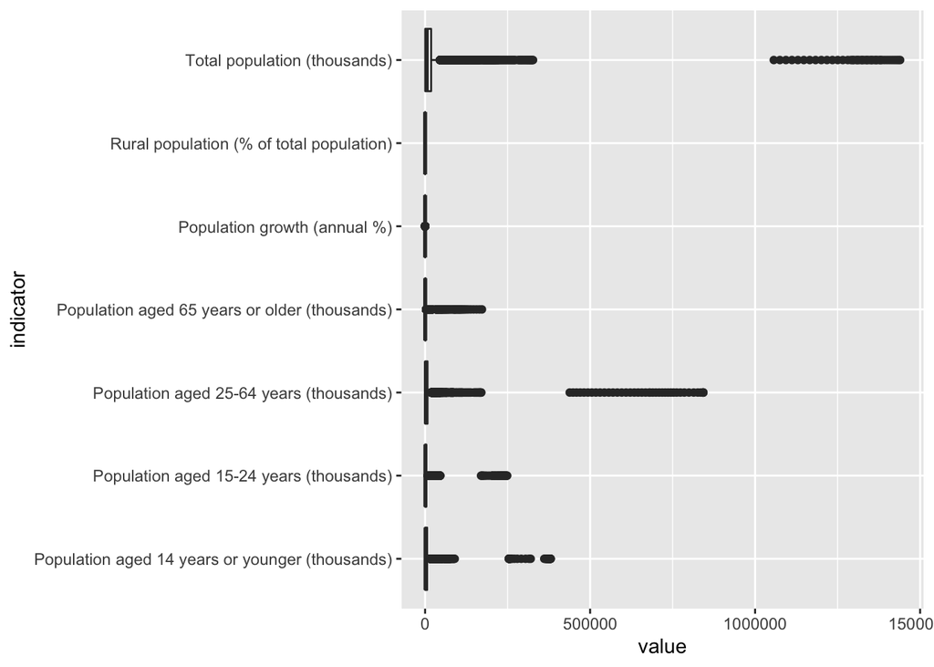

```r
# box plot for the value column in pop grouped by indicator
ggplot(pop, aes(x = value, y = indicator)) +
  geom_boxplot()
```

This time the data is heavily right-skewed. The boxes of each plot are barely visible as they are concentrated around the 0 mark, but there are some extremely high values, which will be the values for the world’s most populous countries.

## 3.3 Preparing to Join

Ultimately I would like to join these two datasets together so that I can report population by the matching demographic in the literacy dataset. The population data has categories by age, but not by sex, so there will be some missing data in the resulting join but it will serve the purposes I need for my analysis.

To get the datasets ready to join, I need to prepare the joining columns so that the column headings match in each dataset and contain the same type of data. Any non-joining columns will need to have distinct names in each dataset.

# 4 Cleaning

Based on the inspection above, I have identified the following cleaning actions that are required:

- Drop the `sdg_ind` and `time_2` columns from `lit`.
- Drop the `demo_ind` and `time_2` columns from `pop`.
- Rename `time` as `year`.
- Rename `value` as `literacy_rate` in `lit` to distinguish it from the `value` column in the `pop` data.
- Rename `value` as `population` in `pop` to distinguish it from the `value` column in the `lit` data.
- Rename `flag_codes` and `flags` in each dataset with a prefix to denote which dataset they are from.
- Drop the rows in `pop` relating to indicators for annual population growth and rural population percentage.
- Convert percentages to proportions (between 0 and 1) in the `lit` dataset.
- Convert population counts to the full number by multipying by 1000 in the `pop` dataset.
- Impute values for 2021 population estimates in `pop`.
- Prepare the `indicator` column in each dataset for joining by splitting into constituent parts: `name`, `age_demographic`, `sex_demographic` (for `lit` only) and `units`.

I will save these changes into new variables so that we retain a copy of the original data.

## 4.1 Drop Columns

I will drop the `sdg_ind` and `time_2` columns from `lit`.

```r
# drop unecessary column from literacy data
lit_c <- lit %>%
  select(!c(sdg_ind, time_2))

# check the results
names(lit_c)
```

```
## [1] "indicator"  "location"   "country"    "time"       "value"
## [6] "flag_codes" "flags"
```

I will drop the `demo_ind` and `time_2` columns from `pop`.

```r
# drop unnecessary columns from the population data
pop_c <- pop %>%
  select(!c(demo_ind, time_2))

# check the results
names(pop_c)
```

```
## [1] "indicator"  "location"   "country"    "time"       "value"
## [6] "flag_codes" "flags"
```

## 4.2 Rename Columns

I will rename the columns as described above in both datasets.

```r
# rename columns in literacy data
lit_c <- lit_c %>%
  rename(year = time,
         literacy_rate = value,
         lit_flag_codes = flag_codes,
         lit_flags = flags)

# check the results
names(lit_c)
```

```
## [1] "indicator"      "location"       "country"        "year"
## [5] "literacy_rate"  "lit_flag_codes" "lit_flags"
```

```r
# rename columns in the population data
pop_c <- pop_c %>%
  rename(year = time,
         population = value,
         pop_flag_codes = flag_codes,
         pop_flags = flags)

# check results
names(pop_c)
```

```
## [1] "indicator"      "location"       "country"        "year"
## [5] "population"     "pop_flag_codes" "pop_flags"
```

## 4.3 Drop Rows

I will drop the rows in `pop` relating to indicators for annual population growth and rural population percentage.

```r
# drop rows for unnecessary indicators in pop
pop_c <- pop_c %>%
  filter(!indicator %in% c("Population growth (annual %)",
                           "Rural population (% of total population)"))

# check the results
unique(pop_c$indicator)
```

```
## [1] "Population aged 25-64 years (thousands)"
## [2] "Total population (thousands)"
## [3] "Population aged 65 years or older (thousands)"
## [4] "Population aged 14 years or younger (thousands)"
## [5] "Population aged 15-24 years (thousands)"
```

## 4.4 Convert Values

In the `lit` dataset I want to convert the percentages to be a number between 0 and 1.

```r
# convert percentages to proportions (decimal values)
lit_c <- lit_c %>%
  mutate(literacy_rate = literacy_rate / 100)

# check the result
lit_c$literacy_rate %>%
  summary()
```

```
##     Min.  1st Qu.   Median     Mean  3rd Qu.     Max.
## 0.001902 0.661203 0.863145 0.781272 0.967496 1.000000
```

In the `pop` dataset I want to convert the population counts to be full numbers (not in thousands).

```r
# convert population counts to full numbers
pop_c <- pop_c %>%
  mutate(population = population * 1000)

# check the result
pop_c$population %>%
  summary()
```

```
##      Min.   1st Qu.    Median      Mean   3rd Qu.      Max.      NA's
## 1.000e+03 1.010e+05 1.124e+06 1.215e+07 5.895e+06 1.439e+09       309
```

## 4.5 Impute 2021 Population Values

The simplest way to impute these values will be to assume the 2020 value. To do this, I will extract the 2020 values from the `pop_c` dataframe, convert the year to 2021 and then bind those back as new rows to `pop_c`

```r
# extract 2020 values and relabel as 2021
pop_c_2021 <- pop_c %>%
  filter(year == 2020) %>%
  mutate(year = 2021)

# bind rows onto pop_c
pop_c <- pop_c %>%
  bind_rows(pop_c_2021)

# check results
pop_c %>%
  arrange(location, indicator, desc(year)) %>%
  head(5) %>%
  kable()
```

| indicator | location | country | year | population | pop_flag_codes | pop_flags |
| --- | --- | --- | --- | --- | --- | --- |
| Population aged 14 years or younger (thousands) | ABW | Aruba | 2021 | 19000 | NA | NA |
| Population aged 14 years or younger (thousands) | ABW | Aruba | 2020 | 19000 | NA | NA |
| Population aged 14 years or younger (thousands) | ABW | Aruba | 2019 | 19000 | NA | NA |
| Population aged 14 years or younger (thousands) | ABW | Aruba | 2018 | 19000 | NA | NA |
| Population aged 14 years or younger (thousands) | ABW | Aruba | 2017 | 19000 | NA | NA |

## 4.6 Split `indicator`

### 4.6.1 Literacy Data

To help me understand how to split this data I will look again at the unique values we have.

```r
lit %>%
  select(indicator) %>%
  distinct() %>%
  kable()
```

| indicator |
| --- |
| Youth literacy rate, population 15-24 years, female (%) |
| Adult literacy rate, population 15+ years, female (%) |
| Adult literacy rate, population 15+ years, male (%) |
| Youth literacy rate, population 15-24 years, both sexes (%) |
| Youth literacy rate, population 15-24 years, male (%) |
| Elderly literacy rate, population 65+ years, male (%) |
| Literacy rate, population 25-64 years, male (%) |
| Literacy rate, population 25-64 years, female (%) |
| Elderly literacy rate, population 65+ years, female (%) |
| Adult literacy rate, population 15+ years, both sexes (%) |
| Literacy rate, population 25-64 years, both sexes (%) |
| Elderly literacy rate, population 65+ years, both sexes (%) |

- The part before the first comma (`,`) can be considered as the `indicator_name`.
- The part before the second comma can be considered as the `age_demographic`.
- The part before the third comma can be considered as the `sex_demographic`.
- The part in parentheses can be considered as the `units`.

I will make the split using the `separate()` function. The separate function takes an argument called `sep` that allows us to define one or more delimiters detween columns.

```r
# split the indicator column by non-alphanumeric character
lit_c <- lit_c %>%
  separate(col = indicator,
           into = c("indicator_name",
                    "age_demographic",
                    "sex_demographic",
                    "units"),
           sep = "(,|\\(|\\))")

# check the results
lit_c %>%
  head(3) %>%
  kable()
```

| indicator_name | age_demographic | sex_demographic | units | location | country | year | literacy_rate | lit_flag_codes | lit_flags |
| --- | --- | --- | --- | --- | --- | --- | --- | --- | --- |
| Youth literacy rate | population 15-24 years | female | % | 40656 | Oceania (excl. Australia/New Zealand) | 2000 | 0.7217386 | NA | NA |
| Youth literacy rate | population 15-24 years | female | % | 40656 | Oceania (excl. Australia/New Zealand) | 2001 | 0.7264066 | NA | NA |
| Youth literacy rate | population 15-24 years | female | % | 40656 | Oceania (excl. Australia/New Zealand) | 2002 | 0.7307147 | NA | NA |

Now I need to tidy up some of the new values.

```r
lit_c <- lit_c %>%
  # trim whitespace from new variables
  mutate(across(c("indicator_name",
                  "age_demographic",
                  "sex_demographic",
                  "units"),
                str_trim)) %>%
  # remove "population " from age_demographic
  mutate(age_demographic = str_replace(age_demographic,
                                       "population ",
                                       "")) %>%
  # convert sex_demographic to title case
  mutate(sex_demographic = str_to_title(sex_demographic)) %>%
  # drop the units column
  select(!units)

# check the results
lit_c %>%
  head(3) %>%
  kable()
```

| indicator_name | age_demographic | sex_demographic | location | country | year | literacy_rate | lit_flag_codes | lit_flags |
| --- | --- | --- | --- | --- | --- | --- | --- | --- |
| Youth literacy rate | 15-24 years | Female | 40656 | Oceania (excl. Australia/New Zealand) | 2000 | 0.7217386 | NA | NA |
| Youth literacy rate | 15-24 years | Female | 40656 | Oceania (excl. Australia/New Zealand) | 2001 | 0.7264066 | NA | NA |
| Youth literacy rate | 15-24 years | Female | 40656 | Oceania (excl. Australia/New Zealand) | 2002 | 0.7307147 | NA | NA |

### 4.6.2 Population Data

To help me understand how to split this data I will look again at the unique values.

```r
pop_c %>%
  select(indicator) %>%
  distinct() %>%
  kable()
```

| indicator |
| --- |
| Population aged 25-64 years (thousands) |
| Total population (thousands) |
| Population aged 65 years or older (thousands) |
| Population aged 14 years or younger (thousands) |
| Population aged 15-24 years (thousands) |

Looking at this I need to make a few changes:

- I can drop the rows for ‘Total Population (thousands)’ and ‘Population aged 14 years or younger (thousands)’ as they don’t link to any of the rows in the `lit` dataset.
- I need to derive data for the population aged 15+ years by adding together the values for 15-24, 25-64 and 65+.

First I drop the unnecessary rows.

```r
# drop rows for further unnecessary indicators in pop
pop_c <- pop_c %>%
  filter(!indicator %in% c("Total population (thousands)",
                           "Population aged 14 years or younger (thousands)"))

# check the results
unique(pop_c$indicator)
```

```
## [1] "Population aged 25-64 years (thousands)"
## [2] "Population aged 65 years or older (thousands)"
## [3] "Population aged 15-24 years (thousands)"
```

Next, I rename the current values for indicator with values that will match the `lit` data.

```r
# rename indicators to match lit data
pop_c <- pop_c %>%
  mutate(indicator = case_when(
    grepl("25-64", indicator) ~ "25-64 years",
    grepl("65", indicator) ~ "65+ years",
    grepl("15-24", indicator) ~ "15-24 years"))

# check the results
unique(pop_c$indicator)
```

```
## [1] "25-64 years" "65+ years"   "15-24 years"
```

Now I pivot this data temporarily to allow me to calculate the new value.

```r
# pivot the indicators to wide format
pop_c <- pop_c %>%
  pivot_wider(names_from = indicator,
              values_from = population)

# check the results
pop_c %>%
  head(3) %>%
  kable()
```

| location | country | year | pop_flag_codes | pop_flags | 25-64 years | 65+ years | 15-24 years |
| --- | --- | --- | --- | --- | --- | --- | --- |
| CYM | Cayman Islands | 2000 | NA | NA | 27000 | 2000 | 5000 |
| CYM | Cayman Islands | 2001 | NA | NA | 28000 | 3000 | 5000 |
| CYM | Cayman Islands | 2002 | NA | NA | 29000 | 3000 | 5000 |

Now I can calculate the new variable.

```r
# calculate a value for population aged 15+
pop_c <- pop_c %>%
  mutate(`15+ years` = `15-24 years` +
                       `25-64 years` +
                       `65+ years`)

# check the results
pop_c %>%
  head(3) %>%
  kable()
```

| location | country | year | pop_flag_codes | pop_flags | 25-64 years | 65+ years | 15-24 years | 15+ years |
| --- | --- | --- | --- | --- | --- | --- | --- | --- |
| CYM | Cayman Islands | 2000 | NA | NA | 27000 | 2000 | 5000 | 34000 |
| CYM | Cayman Islands | 2001 | NA | NA | 28000 | 3000 | 5000 | 36000 |
| CYM | Cayman Islands | 2002 | NA | NA | 29000 | 3000 | 5000 | 37000 |

Lastly, I can re-pivot the data so that indicators fall into a single column.

```r
# pivot the population columns to a single column
pop_c <- pop_c %>%
  pivot_longer(cols = contains("years"),
               names_to = "age_demographic",
               values_to = "population")

# check the results
pop_c %>%
  head(3) %>%
  kable()
```

| location | country | year | pop_flag_codes | pop_flags | age_demographic | population |
| --- | --- | --- | --- | --- | --- | --- |
| CYM | Cayman Islands | 2000 | NA | NA | 25-64 years | 27000 |
| CYM | Cayman Islands | 2000 | NA | NA | 65+ years | 2000 |
| CYM | Cayman Islands | 2000 | NA | NA | 15-24 years | 5000 |

## 4.7 Join the Datasets

Now I am ready to join the two datasets. I will start by looking at the column names in each dataset.

```r
names(lit_c)
```

```
## [1] "indicator_name"  "age_demographic" "sex_demographic" "location"
## [5] "country"         "year"            "literacy_rate"   "lit_flag_codes"
## [9] "lit_flags"
```

```r
names(pop_c)
```

```
## [1] "location"        "country"         "year"            "pop_flag_codes"
## [5] "pop_flags"       "age_demographic" "population"
```

The joining columns will be `location`, `country`, `year` and `age_demographic`. I want to be sure that the `country` column follows the same naming conventions for countries in both datasets (meaning that each value of `location` has the same value of `country` in both datasets).

```r
# check that locations and countries are the same in the two
# get unique country values from lit
lit_countries <- lit_c %>%
  select(location, country) %>%
  rename(lit_country = country) %>%
  distinct()

# get unique country values from pop
pop_countries <- pop_c %>%
  select(location, country) %>%
  rename(pop_country = country) %>%
  distinct()

# join the country values together
join_countries <- lit_countries %>%
  full_join(pop_countries)

# check if the country names match
join_countries <- join_countries %>%
  mutate(match = lit_country == pop_country)

# return any false matches
join_countries %>%
  filter(match == FALSE)
```

```
## # A tibble: 0 x 4
## # … with 4 variables: location <chr>, lit_country <chr>, pop_country <chr>,
## #   match <lgl>
```

Great there are no results here, so the country names match up perfectly. I can go ahead and join the two datasets and save the results to a final dataframe `df`.

```r
# join the datasets
df <- lit_c %>%
  left_join(pop_c)

# check the results
df %>%
  head(3) %>%
  kable()
```

| indicator_name | age_demographic | sex_demographic | location | country | year | literacy_rate | lit_flag_codes | lit_flags | pop_flag_codes | pop_flags | population |
| --- | --- | --- | --- | --- | --- | --- | --- | --- | --- | --- | --- |
| Youth literacy rate | 15-24 years | Female | 40656 | Oceania (excl. Australia/New Zealand) | 2000 | 0.7217386 | NA | NA | NA | NA | NA |
| Youth literacy rate | 15-24 years | Female | 40656 | Oceania (excl. Australia/New Zealand) | 2001 | 0.7264066 | NA | NA | NA | NA | NA |
| Youth literacy rate | 15-24 years | Female | 40656 | Oceania (excl. Australia/New Zealand) | 2002 | 0.7307147 | NA | NA | NA | NA | NA |

# 5 Exploratory Data Analysis

## 5.1 Q1. Which countries are still working towards the 2030 youth literacy goals?

The goal states that by 2030, all youth should achieve literacy and numeracy. For the purposes of my analysis I will assume that any country that has achieved a literacy rate of 95% or greater has achieved the goal. I will take the literacy rate from the most recently available year for each country in order to determine whether they have met the goal.

I will create a subset of the original data which is filtered to the most recent year for each location and demographic, and then determine whether the country has met the goal or not. I can then join this information back into the original `df`.

```r
# create a helper df to determine whether the youth goal has
# been met for each location and sex demographic.
df_youth_met <- df %>%
  filter(indicator_name == "Youth literacy rate") %>%
  group_by(location, sex_demographic) %>%
  slice_max(year) %>%
  ungroup() %>%
  mutate(youth_goal_met = if_else(literacy_rate >= 0.95,
                                  TRUE,
                                  FALSE))

# join the youth goal status back into df
df <- df %>%
  left_join(df_youth_met)
```

Now I can generate a table of the countries that are still working towards the 2030 youth literacy goal and their current (most recent) youth literacy rates.

```r
# subset the data
q1 <- df %>%
  filter(youth_goal_met == FALSE,           # keeps unmet only
         sex_demographic == "Both Sexes",   # both sexes only
         grepl("\\D", location)) %>%        # exclude regional aggs
  select(country, literacy_rate) %>%
  arrange(literacy_rate)

# generate a table caption
q1_cpt <- paste("List of",nrow(q1),"countries still working towards 2030 youth literacy goals")

# print the table with caption
q1 %>%
  kable(caption=q1_cpt)
```

List of 59 countries still working towards 2030 youth literacy goals

| country | literacy_rate |
| --- | --- |
| Chad | 0.3079161 |
| Central African Republic | 0.3826865 |
| Niger | 0.4346000 |
| Mali | 0.4615734 |
| South Sudan | 0.4790096 |
| Guinea | 0.5394052 |
| Liberia | 0.5539870 |
| Afghanistan | 0.5592940 |
| Burkina Faso | 0.5887398 |
| Guinea-Bissau | 0.6040235 |
| Benin | 0.6094808 |
| Mauritania | 0.6394781 |
| Sierra Leone | 0.6664860 |
| Gambia | 0.6716138 |
| Papua New Guinea | 0.6790000 |
| Senegal | 0.6947841 |
| Mozambique | 0.7091245 |
| Pakistan | 0.7270356 |
| Ethiopia | 0.7275482 |
| Malawi | 0.7293561 |
| Sudan | 0.7300000 |
| Nigeria | 0.7502875 |
| Yemen | 0.7700000 |
| Angola | 0.7743113 |
| Sudan (pre-secession) | 0.7815559 |
| Comoros | 0.7827039 |
| Madagascar | 0.7985117 |
| Congo | 0.8205479 |
| Haiti | 0.8299425 |
| Timor-Leste | 0.8353903 |
| Côte d’Ivoire | 0.8362647 |
| Belize | 0.8422305 |
| Democratic Republic of the Congo | 0.8498951 |
| Cameroon | 0.8508000 |
| United Republic of Tanzania | 0.8575514 |
| Rwanda | 0.8649277 |
| Lesotho | 0.8663220 |
| Kenya | 0.8783000 |
| Togo | 0.8789144 |
| Egypt | 0.8819256 |
| Burundi | 0.8822177 |
| Uganda | 0.8939631 |
| Gabon | 0.8978366 |
| Zimbabwe | 0.9042812 |
| Nicaragua | 0.9157178 |
| India | 0.9166404 |
| Zambia | 0.9209157 |
| Cambodia | 0.9221236 |
| Puerto Rico | 0.9238983 |
| Nepal | 0.9239381 |
| Syrian Arab Republic | 0.9245381 |
| Lao People’s Democratic Republic | 0.9246264 |
| Ghana | 0.9249097 |
| Bhutan | 0.9309063 |
| Eritrea | 0.9327239 |
| Iraq | 0.9350000 |
| Bangladesh | 0.9446178 |
| Guatemala | 0.9460415 |
| Qatar | 0.9464411 |

## 5.2 Q2. Which countries are the biggest contributors to global youth illiteracy?

To answer this question, I want to look at how many illiterate people each country is contributing to the total based on their youth literacy rate and youth population estimate. Then I can determine the biggest contributors by population. While the table above shows that there are countries with extremely low literacy rates, some of those countries have relatively low populations. It will be interesting to see whether some of the more populous countries (e.g. India) are making a bigger contribution to youth illiteracy depsite having a higher literacy rate.

First I need to add a column for the illiteracy rate (which is 1 minus the literacy rate) and the total illiterate population, which is the illiteracy rate multiplied by the total population.

```r
# add columns for illiteracy rate and illiterate population
df <- df %>%
  mutate(illiteracy_rate = 1 - literacy_rate,
         illiterate_population = illiteracy_rate * population)

# check the results
df %>%
  filter(!is.na(illiterate_population)) %>%
  select(indicator_name,
         age_demographic,
         sex_demographic,
         location,
         country,
         year,
         literacy_rate,
         illiteracy_rate,
         population,
         illiterate_population) %>%
  head(3) %>%
  kable()
```

| indicator_name | age_demographic | sex_demographic | location | country | year | literacy_rate | illiteracy_rate | population | illiterate_population |
| --- | --- | --- | --- | --- | --- | --- | --- | --- | --- |
| Adult literacy rate | 15+ years | Female | GTM | Guatemala | 2002 | 0.6334138 | 0.3665862 | 6937000 | 2543008 |
| Adult literacy rate | 15+ years | Female | GTM | Guatemala | 2012 | 0.7242804 | 0.2757196 | 9459000 | 2608032 |
| Adult literacy rate | 15+ years | Female | GTM | Guatemala | 2013 | 0.7212759 | 0.2787241 | 9752000 | 2718117 |

Now, I can prepare a table to show the biggest contributors to youth illiteracy by population.

```r
# subset the data
q2 <- df %>%
  filter(youth_goal_met == FALSE,           # keeps unmet only
         sex_demographic == "Both Sexes",   # both sexes only
         grepl("\\D", location)) %>%        # exclude regional aggs
  select(country, illiteracy_rate, illiterate_population) %>%
  arrange(-illiterate_population)

# generate a table caption
q2_cpt <- paste("List of",nrow(q2),"biggest contributors to global youth illiteracy by population")

# print the table with caption
q2 %>%
  kable(caption=q2_cpt)
```

List of 59 biggest contributors to global youth illiteracy by population

| country | illiteracy_rate | illiterate_population |
| --- | --- | --- |
| India | 0.0833596 | 20537888.169 |
| Pakistan | 0.2729644 | 11556493.803 |
| Nigeria | 0.2497125 | 9364718.175 |
| Ethiopia | 0.2724518 | 6272657.791 |
| Afghanistan | 0.4407060 | 3770680.536 |
| Niger | 0.5654000 | 2439701.000 |
| Sudan | 0.2700000 | 2295270.000 |
| Democratic Republic of the Congo | 0.1501049 | 2235212.066 |
| Mali | 0.5384266 | 2167705.492 |
| Chad | 0.6920839 | 2044415.841 |
| Egypt | 0.1180744 | 1973259.373 |
| Bangladesh | 0.0553822 | 1707100.933 |
| Mozambique | 0.2908755 | 1682423.892 |
| Burkina Faso | 0.4112602 | 1628590.392 |
| United Republic of Tanzania | 0.1424486 | 1424913.346 |
| Kenya | 0.1217000 | 1291115.300 |
| Guinea | 0.4605948 | 1223800.384 |
| Angola | 0.2256887 | 1175838.127 |
| South Sudan | 0.5209904 | 1156598.688 |
| Madagascar | 0.2014883 | 1089850.215 |
| Yemen | 0.2300000 | 956110.000 |
| Uganda | 0.1060369 | 939699.008 |
| Malawi | 0.2706439 | 934533.387 |
| Senegal | 0.3052159 | 924498.961 |
| Benin | 0.3905192 | 889993.257 |
| Côte d’Ivoire | 0.1637353 | 870253.120 |
| Cameroon | 0.1492000 | 744955.600 |
| Central African Republic | 0.6173135 | 623486.635 |
| Sierra Leone | 0.3335140 | 517947.242 |
| Iraq | 0.0650000 | 489515.000 |
| Nepal | 0.0760619 | 481015.456 |
| Papua New Guinea | 0.3210000 | 446190.000 |
| Ghana | 0.0750903 | 434923.018 |
| Liberia | 0.4460130 | 408993.921 |
| Haiti | 0.1700575 | 365963.740 |
| Rwanda | 0.1350723 | 325389.171 |
| Syrian Arab Republic | 0.0754619 | 299659.205 |
| Mauritania | 0.3605219 | 297070.046 |
| Zambia | 0.0790843 | 285098.901 |
| Zimbabwe | 0.0957188 | 269065.547 |
| Burundi | 0.1177823 | 249698.476 |
| Cambodia | 0.0778764 | 249048.727 |
| Guatemala | 0.0539585 | 197218.318 |
| Togo | 0.1210856 | 191799.590 |
| Congo | 0.1794521 | 175683.606 |
| Gambia | 0.3283862 | 141862.838 |
| Guinea-Bissau | 0.3959765 | 136215.916 |
| Lao People’s Democratic Republic | 0.0753736 | 106276.776 |
| Nicaragua | 0.0842822 | 101981.462 |
| Lesotho | 0.1336780 | 56679.472 |
| Timor-Leste | 0.1646097 | 45103.058 |
| Eritrea | 0.0672761 | 41980.286 |
| Gabon | 0.1021634 | 37493.968 |
| Comoros | 0.2172961 | 35419.264 |
| Qatar | 0.0535589 | 20780.853 |
| Bhutan | 0.0690937 | 10433.149 |
| Belize | 0.1577695 | 7888.475 |
| Puerto Rico | 0.0761017 | NA |
| Sudan (pre-secession) | 0.2184441 | NA |

# 6 Export

Now all the cleaning is completed I can export the clean dataset back out as a CSV file for use in Tableau.

```r
# write a new csv file for the clean data
write_csv(df, "data/2019-wk46-data-clean.csv")
```